# Week 3 - Probability Thinking

C.A. Kiahtipes

9/2/2023

## Week 3 - Statistics and Probability Thinking with R

There are some base R functions that make good tools for exploring how probability works and for visualizing the properties of our data sets. Now that we are familiar with how to construct the basic object types in R and how to subset them, we can use some other useful functions to gather *descriptive statistics* from a data set.

Weeks 1 and 2 we learned about R objects: * vectors * lists * matrices * data frames

We learned a lot of useful R functions: * is.vector()/is.character()/is.matrix()/etc. * class() * c() - concatenate * length() - give you the length of an object * rep() - repeats something a number of times

### 1.1 Introduction and Outline

The basic purpose of statistics is the collection, organization, and interpretation of data. These are interrelated concepts, so we will build our knowledge gradually in each domain, rather than attempt to master data collection (i.e. sampling and populations) before we advance to data organization.

Today, we’re working with a dataset that I generated with several plant taxa across a given depth. This basically simulates a stratigraphic study. We need to state some assumptions at the outset.

- We have identified a sample of the fossil population.
- All of the identifications are correct.

### 1.2 Downloading R Packages

There is a ton of user-generated code out there that we can use on our own data. One way this code is distributed is through packages, which are hosted by CRAN. Authors of the packages are trusted to maintain them and this does not always happen, so be careful how many dependencies you write into your code. For today’s lab, we need to use one of the functions from the “vioplot” package. Use the code below to make sure it is installed and, if not, download the package.

```r
packages <- c("vioplot") #Make an object listing packages

install.packages(setdiff(packages, row.names(installed.packages()))) #Install any packages that are in the object, but not fount on your  machine.
```

### 1.3 Data Collection Concepts

We have already introduced a range of data types as we’ve become more familiar with R objects. It is helpful to have a working definition of major types of data in mind as we move forward.

Our primary interest is in measuring variation and those categories within which we expect more than two states are defined as *variables*. A strong proportion of paleoecology research is conducted by counting the number of different types of fossil organisms, making each taxon a different variable. These are *fossil variables* (this is my term!)

- Identifications
- Counts
- Morphometrics
- Categorical Assessments (binary or nominal scales)

The other set of variables we are interested in relate to the sites/strata from which we collect this data. These data may be: synchronic, (coming from the present) describing present conditions of the site ; or diachronic, describing changes through time in parallel to the fossil variables. These are *site variables* (again, my terms). We’ve described some of the variables we might derive from sites/strata:

- Temperature
- Elevation (continuous numeric, interval scale)
- pH (continuous numeric, log scale)
- Sediment Composition (numeric continous interval, then ratio scale)
- Chemistry (i.e. dissolved O2).

There are lots of kinds of data that we might collect, which we arrange in different ways. We can get a clearer sense of the importance of how data organization impacts subsequent analyses and interpretation.

## 2. Reading Data and Producing Descriptive Statistics

We will read the fake pollen data set from last week and use some functions to gather insights. We are taking for granted how many variables we are looking at here and how many samples we have collected. We will come back to populations and sampling a little later. For now, let’s concern ourselves with taking some basic measurements from our data set.

```r
fake_core <- read.csv("data/Fake_core.csv",
         header = TRUE,
         row.names = "depth")

ncol(fake_core) #How many variables?
```

```
## [1] 9
```

```r
nrow(fake_core) #How many samples?
```

```
## [1] 100
```

```r
sum(fake_core) #This is the sum of all the values in the table.
```

```
## [1] 21481
```

### 2.1 Descriptive Statistics

Descriptive statistics can offer some initial insights into numeric variables. Let’s look at a handful of basic functions for deriving these descriptive statistics. Let’s derive these for one of the classes of fossils, “Cyperaceae undiff.”. These can be computed with some base R functions, but we will also derive these manually to be sure we understand these measurements.

```r
sum(fake_core$Cyperaceae.undiff.)
```

```
## [1] 2526
```

```r
mean(fake_core$Cyperaceae.undiff.)
```

```
## [1] 25.26
```

```r
sum(fake_core$Cyperaceae.undiff.)/length(fake_core$Cyperaceae.undiff.) #Mean is sum of observations divided by number of observations.
```

```
## [1] 25.26
```

The median value is the middle value of the ranked values for a given variable. It’s the value where 50% of the observations fall above and below it. This also teaches us a couple of new useful base R functions (unique() and order())

```r
median(fake_core$Cyperaceae.undiff.)
```

```
## [1] 25
```

```r
vls_cyp <- unique(fake_core$Cyperaceae.undiff.) #Unique lets us get all of the unique values from our variable.

vls_cyp
```

```
##  [1] 10 11  6 19  9 15 12 14 21 17  7 18 16 22 20 25 32 23 36 30 29 28 34 31 26
## [26] 35 24 33 38 39 37 27 41 46 42 40 45
```

```r
ord_cyp <- vls_cyp[order(vls_cyp)] #Here, we are taking those values and organizing them by rank-order. This works in a cool way.

ord_cyp
```

```
##  [1]  6  7  9 10 11 12 14 15 16 17 18 19 20 21 22 23 24 25 26 27 28 29 30 31 32
## [26] 33 34 35 36 37 38 39 40 41 42 45 46
```

```r
mdn_cyp <- ord_cyp[floor(length(ord_cyp)/2)] #Here, we grab the middle value of the range of numbers. There's differences for even and odd lists of values.

mdn_cyp
```

```
## [1] 25
```

### 2.2 Using Apply to Work Efficiently

We can use the apply() function to take another function (such as mean()) and apply it iteratively to a table of data. This makes our lives a great deal easier when working with tables of taxa. Below, we use apply, which will look for three arguments: a matrix object, a code designating rows/columns, and a function. You can substitute custom functions as well. Below, we apply sum, mean, and median to the entire fake core data set.

```r
fake_sums <- apply(fake_core, 2, sum)

fake_mean <- apply(fake_core, 2, mean)

fake_mode <- apply(fake_core, 2, median)
```

Some other functions also generate informative statistics for us. We can gather quantile estimates (fractions under which 25% of the observations fall) using summary(). Summary can also be used in the apply() format and yields a nice table if we make it an object.

```r
summary(fake_core$Cyperaceae.undiff.)
```

```
##    Min. 1st Qu.  Median    Mean 3rd Qu.    Max.
##    6.00   16.00   25.00   25.26   34.00   46.00
```

```r
fake_smmy <- apply(fake_core, 2, summary)
```

Using barplot(), we can visualize this information relatively quickly.

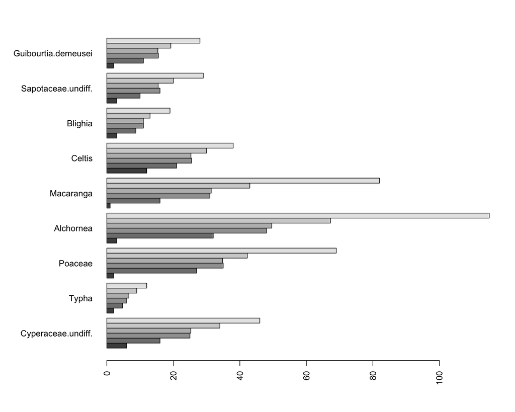

```r
par(mai = c(1, 2, 0.5, 0.5))

barplot(fake_smmy,
        beside = TRUE,
        horiz = TRUE,
        las = 2)
```

```r
par(mar = c(5, 4, 4, 2) + 0.1)
```

These basic statistics show us a few things about our data. We can also plot the distribution of Cyperaceae undiff. counts across the 100 samples and show where the median and the mean fall along this scatter plot.

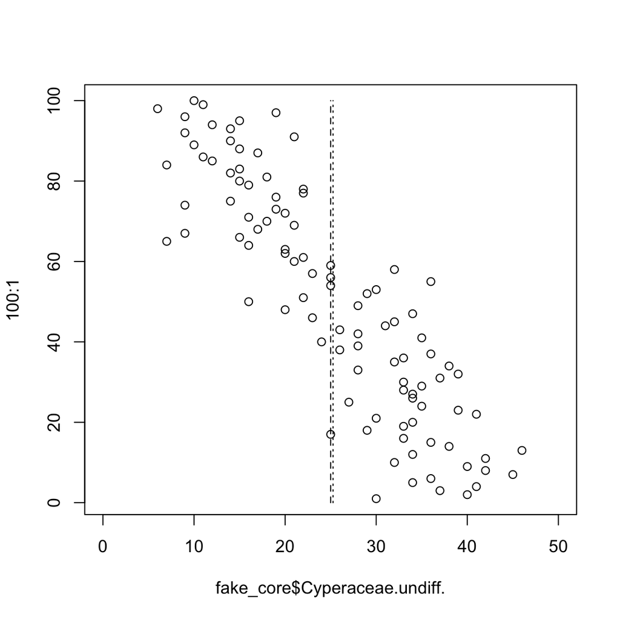

```r
plot(fake_core$Cyperaceae.undiff.,
     100:1,
     xlim = c(0, 50),
     pch = 21)

lines(c(mean(fake_core$Cyperaceae.undiff.),
        mean(fake_core$Cyperaceae.undiff.)),
      c(0, 100),
      lty = 3)

lines(c(median(fake_core$Cyperaceae.undiff.),
        median(fake_core$Cyperaceae.undiff.)),
      c(0, 100),
      lty = 2)
```

## 3. Frequency Distributions

These counts are integers, so we could expect repetition of some numbers. Let’s see what the distribution of individual counts looks like using table(), which will produce a table of counts from a vector of data.

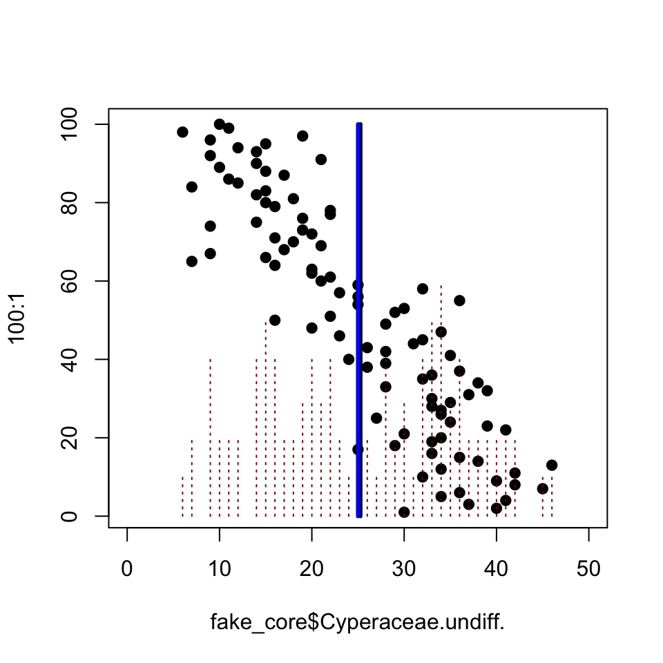

```r
plot(fake_core$Cyperaceae.undiff.,
     100:1,
     xlim = c(0, 50),
     pch = 19)

lines(table(fake_core$Cyperaceae.undiff.)*10,
      lty = 3,
      col = "darkred",
      lwd = 1) #Adding line width argument here, lets us define the width of lines we're plotting.

lines(c(mean(fake_core$Cyperaceae.undiff.),
        mean(fake_core$Cyperaceae.undiff.)),
      c(0, 100),
      lty = 1,
      lwd = 3)

lines(c(median(fake_core$Cyperaceae.undiff.),
        median(fake_core$Cyperaceae.undiff.)),
      c(0, 100),
      lty = 1,
      col = "blue",
      lwd = 3)
```

We can use this basic method to look at other species in our table. Let’s look at *Alchornea*.

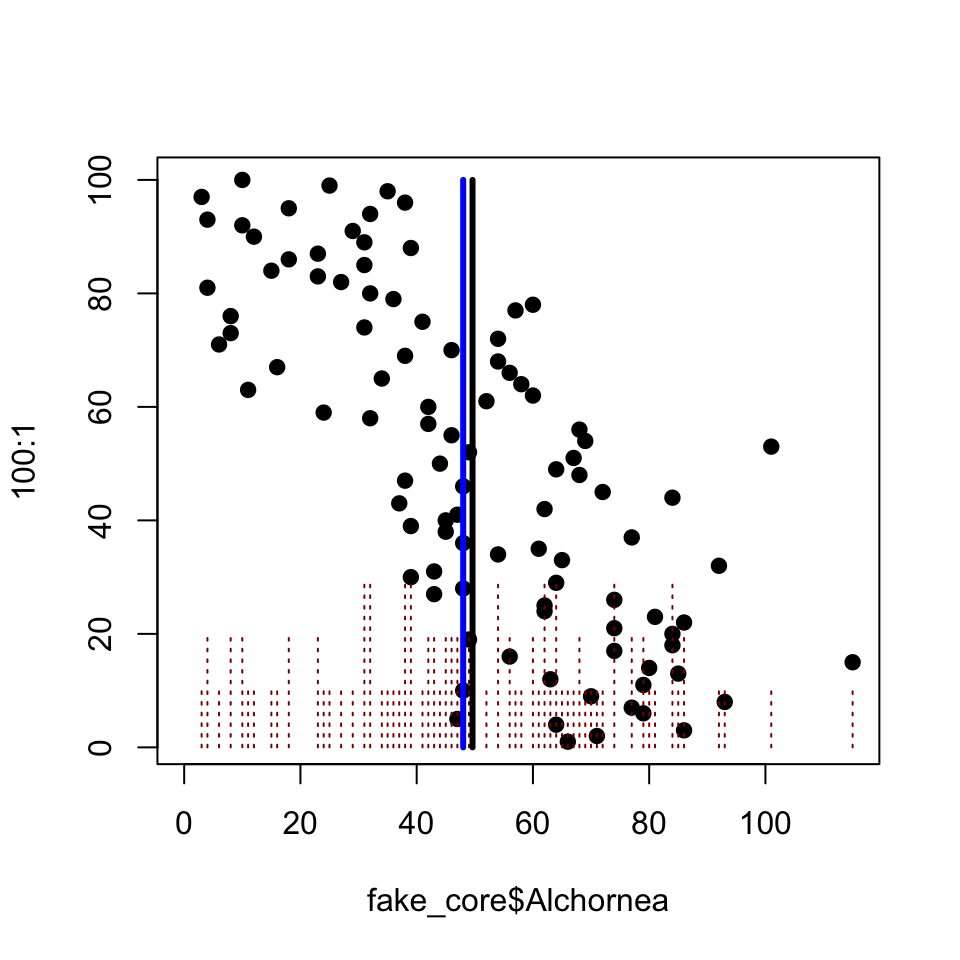

```r
#We could always copy-paste the code we just used, but if we catch ourselves copy-pasting, that means that we may be better off with a function.

plot(fake_core$Alchornea,
     100:1,
     xlim = c(0, max(fake_core$Alchornea)),
     pch = 19)

lines(table(fake_core$Alchornea)*10,
      lty = 3,
      col = "darkred",
      lwd = 1) #Adding line width argument here, lets us define the width of lines we're plotting.

lines(c(mean(fake_core$Alchornea),
        mean(fake_core$Alchornea)),
      c(0, 100),
      lty = 1,
      lwd = 3)

lines(c(median(fake_core$Alchornea),
        median(fake_core$Alchornea)),
      c(0, 100),
      lty = 1,
      col = "blue",
      lwd = 3)
```

### 3.1 Using Functions to Look at Multiple Variables

When looking for ways to build functions, look for repetitions. We repeat the variable (Alchornea) and the functions applied to it. So what if R took any vector and ran all of these commands?

```r
cust_plot = function(x){
  par(mfrow = c(3, 3))
  title_names = colnames(x)
  for(i in 1:ncol(x)){
    plot(x[,i],
       1:length(x[,i]),
       xlim = c(0, max(x[,i])),
       pch = 19,
       xlab = "NISP",
       ylab = "sample")

  lines(rep(mean(x[,i]),2),
        c(0, length(x[,i])),
        lwd = 3)

  lines(rep(median(x[,i]),2),
        c(0, length(x[,i])),
        lwd = 3,
        col = "blue")

  lines((table(x[,i])/sum(table(x[,i])))*100,
        lty = 3,
        col = "darkred",
        lwd = 1)

  title(main = title_names[i])
  axis(4, at = seq(10,100,10), labels = seq(0.1,1,0.1))
  }
  par(mfrow = c(1, 1))
}
```

Now that we have a function that we can use, all we have to do is switch up the inputs. With this limited number of taxa, we can actually plot all of them simultaneously.

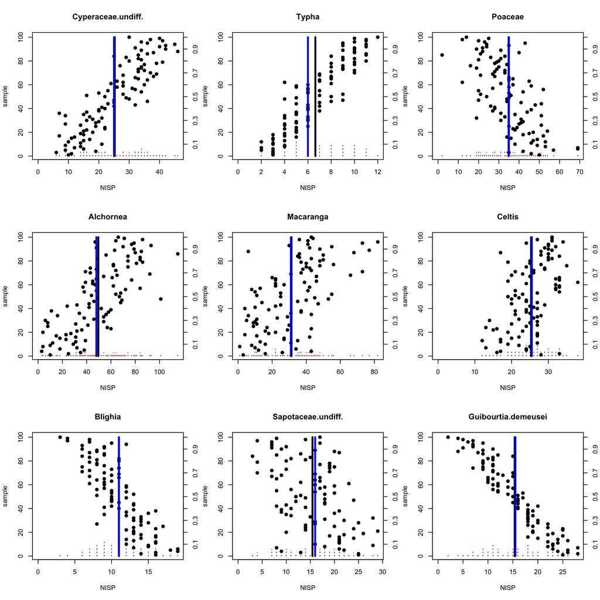

```r
cust_plot(fake_core)
```

### 3.2 Histograms

One of the first questions we might ask is about the *frequency distribution* of a given variable. We can get a sense of this quickly with the histogram function (“hist()”).

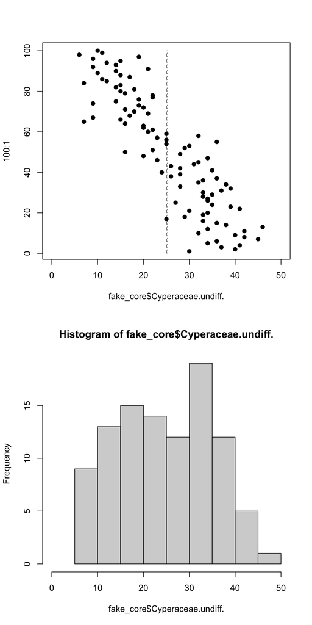

```r
par(mfrow = c(2, 1))

plot(fake_core$Cyperaceae.undiff.,
     100:1,
     xlim = c(0, 50),
     pch = 19)

lines(c(mean(fake_core$Cyperaceae.undiff.),
        mean(fake_core$Cyperaceae.undiff.)),
      c(0, 100),
      lty = 3)

lines(c(median(fake_core$Cyperaceae.undiff.),
        median(fake_core$Cyperaceae.undiff.)),
      c(0, 100),
      lty = 2)

#barplot(table(fake_core$Cyperaceae.undiff.))

hist(fake_core$Cyperaceae.undiff.,
     breaks = 10,
     xlim = c(0,50))
```

```r
par(mfrow = c(1, 1))
```

## 4. More Descriptive Statistics

Now that we have an idea of how we can view our counts as frequency distributions, we can explore some more ways to describe these results.

- Variance
- Standard Deviation

```r
sd(fake_core$Cyperaceae.undiff.) #Calling a single column
```

```
## [1] 10.25495
```

```r
fake_sds = apply(fake_core, 2, sd) #Using apply to get sds of every column

fake_sds
```

```
##  Cyperaceae.undiff.               Typha             Poaceae           Alchornea
##           10.254952            2.630512           12.074449           24.551284
##           Macaranga              Celtis             Blighia  Sapotaceae.undiff.
##           17.936980            5.560130            3.412677            6.049159
## Guibourtia.demeusei
##            6.192819
```

```r
apply(fake_core, 2, var)
```

```
##  Cyperaceae.undiff.               Typha             Poaceae           Alchornea
##          105.164040            6.919596          145.792323          602.765556
##           Macaranga              Celtis             Blighia  Sapotaceae.undiff.
##          321.735253           30.915051           11.646364           36.592323
## Guibourtia.demeusei
##           38.351010
```

```r
sd_cyp <- sum(abs(fake_core$Cyperaceae.undiff. - mean(fake_core$Cyperaceae.undiff.)))/length(fake_core$Cyperaceae.undiff.)

sd_cyp
```

```
## [1] 8.8652
```

### 4.1 Box-and-Whisker Plots

These are useful plots for showing us the basic contours of our data.

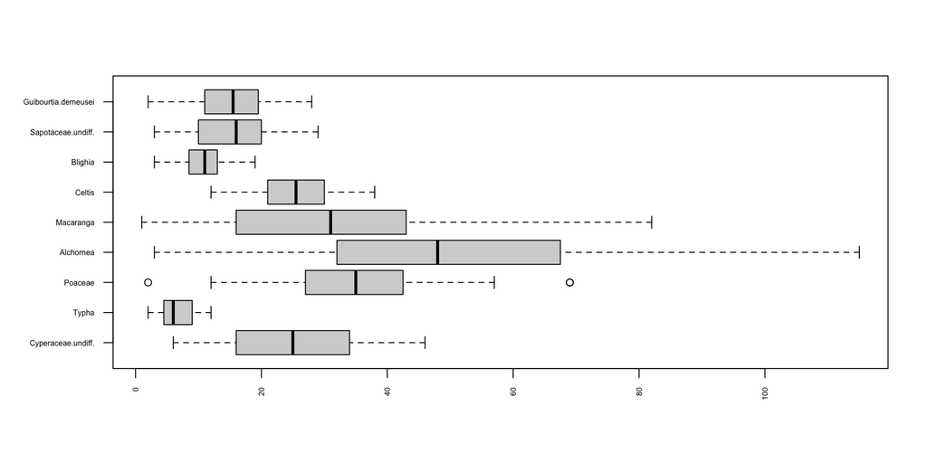

```r
par(mar = c(5, 6, 4, 2) + 0.1)

boxplot(fake_core,
        horizontal = TRUE,
        las = 2,
        cex.axis = 0.5)
```

```r
par(mar = c(5, 4, 4, 2) + 0.1)
```

### 4.2 Kernel Densities and Violin Plots

There are some more useful ways to visualize our data, however. We can use kernel density plots to look at overall distributions of data in a more detailed way. This also helps us get a sense of how normally distributed the data actually are.

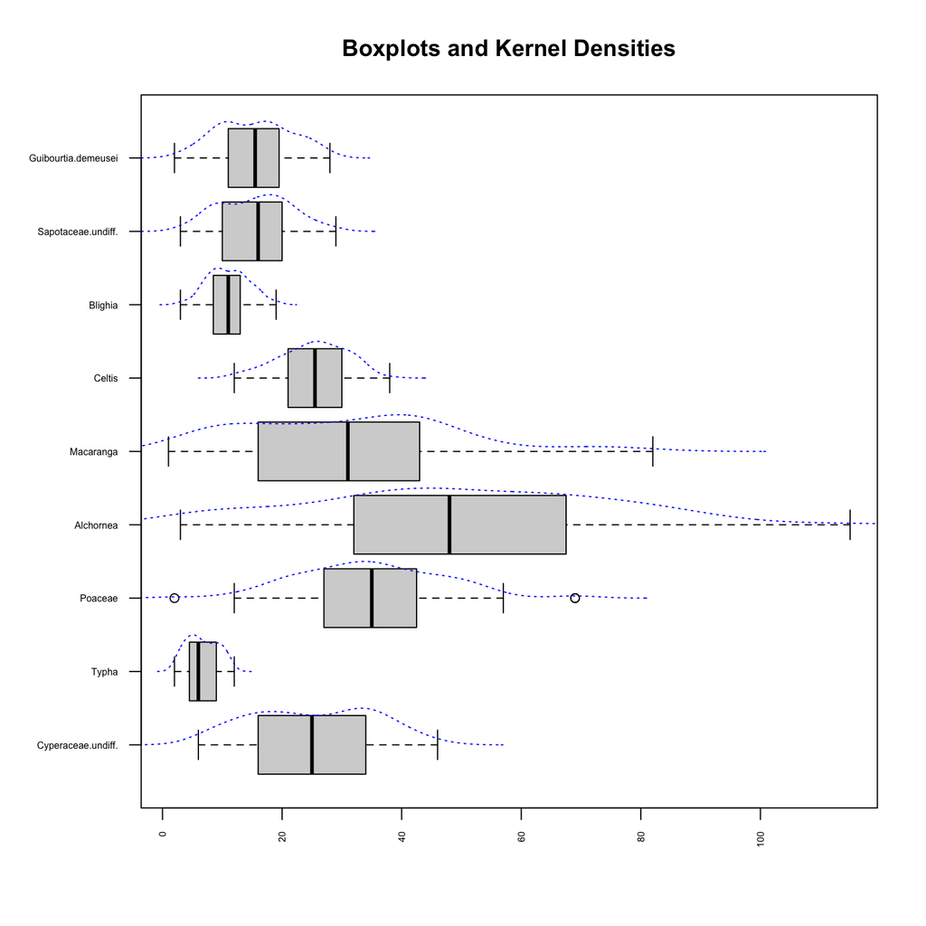

```r
dens_plot = lapply(fake_core, function(x){
  density(x)
})

par(mar = c(5, 6, 4, 2) + 0.1)

boxplot(fake_core,
        horizontal = TRUE,
        las = 2,
        cex.axis = 0.5,
        main = "Boxplots and Kernel Densities")

for(i in 1:length(dens_plot)){
  ylines = (dens_plot[[i]][['y']]/max(dens_plot[[i]][['y']]))*0.5
  lines(dens_plot[[i]][['x']], ylines + i, lty = 3, col = "blue")
}
```

```r
par(mar = c(5, 4, 4, 2) + 0.1)
```

You could also use the violplot method, which uses these densities to create boxplots where the margins are polygons shaped like the densities.

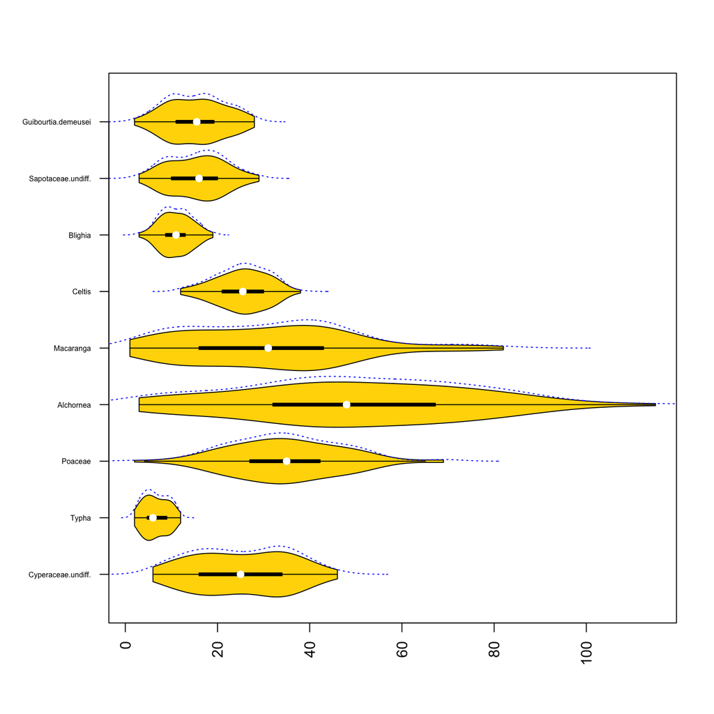

```r
par(mar = c(5, 6, 4, 2) + 0.1)

vioplot::vioplot(fake_core,
        horizontal = TRUE,
        las = 2,
        cex.axis = 0.5,
        col = "gold")

for(i in 1:length(dens_plot)){
  ylines = (dens_plot[[i]][['y']]/max(dens_plot[[i]][['y']]))*0.5
  lines(dens_plot[[i]][['x']], ylines + i, lty = 3, col = "blue")
}
```

```r
par(mar = c(5, 4, 4, 2) + 0.1)
```